# Power computation POSAJE

Sample size: 1687 families minimum. This is based on power calculations using the Powerup software with the following parameters:

1. minimum detectable effect size for the main effect: 0.15; b) randomization procedure as described above; c) R2=40% owing mainly to baseline information on intention to apply for ECS; d) T1=33%, T2=33% C=34%; e) blocks: 9; f) two- tailed alpha level: 5%; g) statistical power: 80%; h) attrition at the endline: 25%.

# Most basic diagnostic

Our experiment has three randomised groups of roughly 600 mothers. The main outcome is application to any childcare, a binary variable with 74% applying in the control group.

In a pure randomised experiment, we are interested in the coefficients $\hat{\beta}$ from the linear probability model:

$$\begin{aligned}
Y=\alpha+\mathbf{Z}_{is}^\prime\beta+\epsilon\\
Y_{is}=\alpha_s+\sum_s\beta_sZ_{is}+\epsilon_{is}\\
\end{aligned}$$
Where $Y_{is}$ equals 1 for application mother $i$ in the sub-sample of comparison pair $s$, with $s \in \{T_1-C,T_2-C,T_2-T_1\}$. The matrix $\mathbf{Z}$ contains three binary vectors $Z_s$ for each treatment arm.

This regression model stacks pairs of treatment arms comparisons and retrieves a constant and a treatment coefficient for each pair. Because Y is binary, standard errors needs to be heteroskedasticity robust and clustered at the individual level since there are repeated observation of the same individuals across pair comparisons.

## Model :

We specify a population of size $N$ where a unit $i$ has a potential outcome, $Y_i(Z=0)$, when it remains untreated and Z(z=1,2) potential outcomes defined according to the treatment that it receives. The effect of each treatment on the outcome of unit $i$ is equal to the difference in the potential outcome under treatment condition $z$ and the control condition: $Y_i(Z=z)−Y_i(Z=0)$.

## inquiry

We are interested in all of the pairwise comparisons between arms: $E\left[Y(z)−Y(z^\prime)\right]$, for all $z,z^\prime \in \{0,1,2\}$

## Data strategy:

We randomly assign $\frac{k}{N}$ units to each of the treatment arms, with blocking.

## Answer strategy:

We take every pairwise difference in means corresponding to the specific estimand.

We simulate data that closely resemble ours with a bit of simplification for clarity.

```
#Sample Size
N <- nrow(MainDB %>% filter(Responded==1))

# We run two basic regression to get the share of high education parents and intention to use by education in the control group.

HighSES <- feols(HighEduc~1,MainDB)

intention <- feols(Intend~0+Educ2,MainDB %>% mutate(Intend=ifelse(IntendUse!="Else",1,0)))
```

High SES represent 61% of the population, 87% of them intend to use childcare, while only 71% of low SES do. Using data from the control group, we can estimate the conditional means of the outcome for these subgroups:

```
C.means <- feols(ECSApp~0+i(Intend,Educ2),MainDB %>% mutate(Intend=ifelse(IntendUse!="Else",1,0)) %>% filter(Assignment=="Control"),se="hetero")
```

```
NOTE: 129 observations removed because of NA values (LHS: 129).
```

[output not shown]

Let’s generate a first sample and potential outcome without intervention. We assume that our sample is *iid* (at least for now) and we first draw an education variable from a Bernoulli trial with probability given by the share of High SES in the sample. The realisation of education generates intention from a Bernoulli trial with probability depending on SES status (alternatively, we could have defined a latent propensity to use and a threshold function depending on education in a Roy model).

```
# Linear probability model of application by intention and education:
modelsummary(list("Simulated"=feols(Y0~0+i(Educ2,factor(Intend)),db0),
                  "Observed"=feols(ECSApp~0+i(Educ2,factor(Intend)),MainDB %>% mutate(Intend=ifelse(IntendUse!="Else",1,0),
                                                                                      Educ2=ifelse(Educ2=="High-SES",1,0)
                                                                                      ))))
```

```
NOTE: 396 observations removed because of NA values (LHS: 396).
```

|  | Simulated | Observed |
| --- | --- | --- |
| Educ2 = 0 × factor(Intend) = 0 | 0.227 | 0.243 |
|  | (0.030) | (0.029) |
| Educ2 = 0 × factor(Intend) = 1 | 0.749 | 0.780 |
|  | (0.019) | (0.018) |
| Educ2 = 1 × factor(Intend) = 0 | 0.361 | 0.345 |
|  | (0.035) | (0.034) |
| Educ2 = 1 × factor(Intend) = 1 | 0.894 | 0.908 |
|  | (0.014) | (0.013) |
| Num.Obs. | 1453 | 1453 |
| R2 | 0.274 | 0.292 |
| R2 Adj. | 0.273 | 0.290 |
| AIC | 1289.9 | 1157.4 |
| BIC | 1311.0 | 1178.6 |
| RMSE | 0.38 | 0.36 |
| Std.Errors | IID | IID |
| Mean of DV | 0.73 | 0.76 |

Comparing the simulated outcome and actual data shows that our simulation works well.

Now, let’s introduce our treatment.

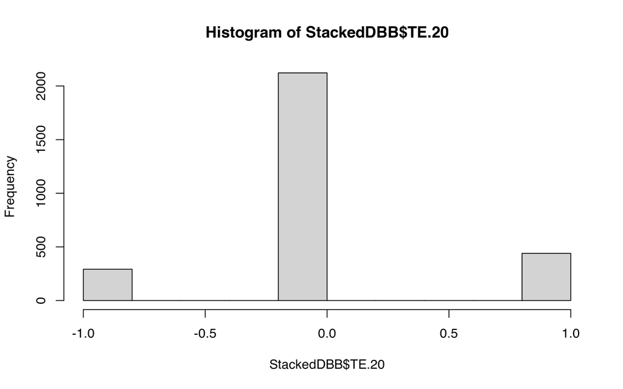

There again, this simulation works well. Now we are ready to create a bootstrap function and simulate this experiment many time.

We can plot the estimates of the simulation of this design. The filled densities are the estimates, the line are the distribution of the simulated estimand.

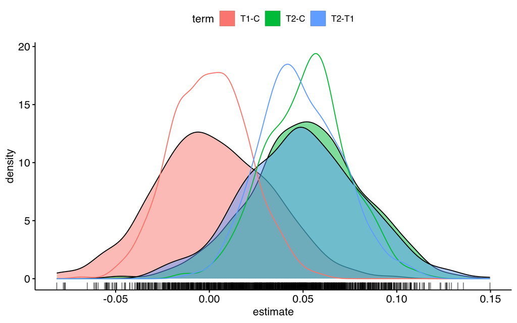

| term | bias | rmse | power | coverage |
| --- | --- | --- | --- | --- |
| T1-C | 0.00188480698 | 0.02165028 | 0.080 | 0.96 |
| T2-C | 0.00009638624 | 0.02113090 | 0.312 | 0.96 |
| T2-T1 | 0.00110632904 | 0.02208456 | 0.310 | 0.96 |

```r
BootConstantITT <- function(ATE1=0,ATE2=.05,nboot=500,N=1850){

  results <- c()
  N = {{N}}
  for (boot in 1:nboot){
Educ2 = rbinom(N, size = 1, prob = HighSES$coefficients[1])

#Define intention to use as a binary variable with conditional probability different by education, drawn from the regression tables
Intend = rbinom(N,size=1,
                prob=Educ2*intention$coefficients["Educ2High-SES"]+
                  (1-Educ2)*intention$coefficients["Educ2Low-SES"])

#define Blocks with the intersection of the two variables

block=case_when(
                (Educ2==0 & Intend==0)~0,
                (Educ2==0 & Intend==1)~1,
                (Educ2==1 & Intend==0)~2,
                (Educ2==1 & Intend==1)~3
              )

# We can define the potential outcome in the absence of the program similarly:

Y0.star =
             case_when(
              (Educ2==1 & Intend==1) ~ rnorm( N, High.Intend,  C.means$se["Intend::1:Educ2::High-SES"]),
              (Educ2==0 & Intend==1) ~ rnorm( N, Low.Intend,   C.means$se["Intend::1:Educ2::Low-SES"]),
              (Educ2==1 & Intend==0) ~ rnorm( N, High.NoIntend,C.means$se["Intend::0:Educ2::High-SES"]),
              (Educ2==0 & Intend==0) ~ rnorm( N, Low.NoIntend, C.means$se["Intend::0:Educ2::Low-SES"])
)

Y0=rbinom(N,size=1,prob=Y0.star)

# We use block random assignment
Z = block_ra(blocks=block, prob_each = c(.34,.33,.33), conditions = c("0", "1", "2"))

# Like in our results, let's simulate a null effect of T1 and a 5PP itt of T2
#

Y1 = rbinom(N,
           size=1,
           prob=Y0.star+rnorm(N,0+{{ATE1}},sd=.02))



Y2 = rbinom(N,
           size=1,
           prob=Y0.star+rnorm(N,0+{{ATE2}},sd=.02))


Y.obs=case_when(Z==0~Y0,Z==1~Y1,Z==2~Y2)


db0 <- data.frame(Educ2,Intend,block,Y.obs,Y1,Y2,Z,Y0,Y0.star)

# like in our analysis, we build pair of comparison
db0 <- db0 %>% mutate(id=cur_group_rows())

T2T1 <- db0 %>% filter(Z %in% c(1,2)) %>% mutate(SubSample="T2-T1",Z1=ifelse(Z==2,1,0))
T2T0 <- db0 %>% filter(Z %in% c(0,2)) %>% mutate(SubSample="T2-C",Z1=ifelse(Z==2,1,0))
T1T0 <- db0 %>% filter(Z %in% c(0,1)) %>% mutate(SubSample="T1-C",Z1=ifelse(Z==1,1,0))

StackedDB <- bind_rows(T2T1,T2T0,T1T0) %>% mutate(SubSampleStrata=interaction(SubSample,block),
                                                  StrataWave=block,
                                                  weights=1
                                                  )


estimates <- ITTSimultaneous(Y="Y.obs",treat = "Z1",DB=StackedDB,weights = "weights")

results <- bind_rows(results,estimates$Tidy %>% mutate(Boot=boot))
  }
  return(results)
}


BootConstantITT(nboot = 10)
```

```r
N <- 1850

outcome_means <- c(0.75, .8, .85)
sd_i <- sqrt(.75*.25)
outcome_sds <- c(0, 0, 0)

#
# population <- fabricate(
#   N = N,
#   latent_intend = runif(N, 0, 1),
#   SES = rbinom(N,1,.6+rnorm(N)),
#   turnout = draw_binary(prob = ifelse(latent_intend < .6, 0.6, 0.75), N=N)
# )
#

#table(PostDB$IntendUse,PostDB$Educ2)

intention <- feols(Intend~0+Educ2,MainDB %>% mutate(Intend=ifelse(IntendUse!="Else",1,0)))

HighSES <- feols(HighEduc~1,MainDB)

# High SES represent 60% of the population, 86% of them intend to use childcare, 71% of low SES intend to use childcare.

# Using data from the control group, we can estimate the conditional means for these subgroups

C.means <- feols(ECSApp~0+i(Intend,Educ2),MainDB %>% mutate(Intend=ifelse(IntendUse!="Else",1,0)) %>% filter(Assignment=="Control"))


# We think application baseline are divided into these 4 subgroups

Low.NoIntend <- C.means$coefficients["Intend::0:Educ2::Low-SES"]
High.NoIntend <- C.means$coefficients["Intend::0:Educ2::High-SES"]
Low.Intend <- C.means$coefficients["Intend::1:Educ2::Low-SES"]
High.Intend <- C.means$coefficients["Intend::1:Educ2::High-SES"]

U <- rnorm(N,HighSES$coefficients[1],sqrt(HighSES$coefficients[1]))

Educ2 = rbinom(N, size = 1, prob = HighSES$coefficients[1])
Intend = rbinom(N,size=1,
                prob=Educ2*intention$coefficients["Educ2High-SES"]+
                  (1-Educ2)*intention$coefficients["Educ2Low-SES"])

Y0 = rbinom(N,
           size=1,
           prob=
             case_when(
              (Educ2==1 & Intend==1) ~ rnorm( N, High.Intend,  C.means$se["Intend::1:Educ2::High-SES"]),
              (Educ2==0 & Intend==1) ~ rnorm( N, Low.Intend,   C.means$se["Intend::1:Educ2::Low-SES"]),
              (Educ2==1 & Intend==0) ~ rnorm( N, High.NoIntend,C.means$se["Intend::0:Educ2::High-SES"]),
              (Educ2==0 & Intend==0) ~ rnorm( N, Low.NoIntend, C.means$se["Intend::0:Educ2::Low-SES"])
))

block=case_when((Educ2==0 & Intend==0)~0,
                                                 (Educ2==0 & Intend==1)~1,
                                                 (Educ2==1 & Intend==0)~2,
                                                 (Educ2==1 & Intend==1)~3
                                                 )


Y1 <- Y+ Educ2*.05+(1-Educ2)*(Z==1)*.05+Educ2*(Z==2)*.1+(1-Educ2)*(Z==2)*.1+(1-Educ2)*(1-Intend)*.2*(Z==2)


Z = block_ra(blocks=block, prob_each = c(.34,.33,.33), conditions = c("0", "1", "2"))



u_1 = rnorm(N, 0, outcome_sds[1L])
u_2 = rnorm(N, 0, outcome_sds[2L])
u_3 = rnorm(N, 0, outcome_sds[3L])
u = rnorm(N) * sd_i


feols(Y1~Z|block,data.frame(Y1,block,Z)) %>% modelsummary()



#
#
# multi_arm_design <- population + potential_outcomes + assignment +
#   reveal_Y + estimand + estimator
#
# diagnosis <- diagnose_design(multi_arm_design, sims = 1000)
```